# Measles Outbreaks

Elizabeth Giacobe

## Research Question

- How does the measles virus spread over time, in different areas, and in different conditions such as population, population density, and average commute distance?

## Set Up

```r
#clean ups
rm(list = ls())

#loaded needed packages
library(tidyverse)
library(rvest)
library(rpart)
library(rpart.plot)
```

## Data Access

I accessed all data that will be used to address the research question. The Measles data was downloaded from the World Health Organization’s free database. The other data on the different countries was pulled from various published websites. This section is significant to the project because it is where I will get all of the data.

### Commute Distance Data

```r
page2 <- "https://www.nationmaster.com/country-info/stats/Transport/Commute/Distance"
tableList2 <- page2 %>%
  read_html() %>%
  html_nodes(css = "table") %>%
  html_table(fill = TRUE)

RawTransport <- tableList2[[1]]

head(RawTransport)
```

|  | # | COUNTRY | AMOUNT | DATE | GRAPH |
| --- | --- | --- | --- | --- | --- |
| 1 | 1 | Egypt | 39.82 km | 2014 | NA |
| 2 | 2 | Singapore | 24 km | 2013 | NA |
| 3 | 3 | Denmark | 22.67 km | 2014 | NA |
| 4 | 4 | Japan | 18.88 km | 2014 | NA |
| 5 | 5 | Taiwan | 17.5 km | 2014 | NA |
| 6 | 6 | Bangladesh | 14.67 km | 2013 | NA |

Note: There are many variables that aren’t needed. The distances have units in them and they are character strings.

### Population Density Data

```r
page1 <- "http://worldpopulationreview.com/countries/countries-by-density/"
tableList1 <- page1 %>%
  read_html() %>%
  html_nodes(css = "table") %>%
  html_table(fill = TRUE)

RawCountries <- tableList1[[1]]

head(RawCountries)
```

|  | X1 | X2 | X3 | X4 | X5 | X6 |
| --- | --- | --- | --- | --- | --- | --- |
| 1 | Rank | Country | Density (km²) | Density (mi²) | Population 2019 | Area |
| 2 | 114 | Macau | 21,348/km² | 55,292/mi² | 640,445 | 30 km² |
| 3 | 116 | Monaco | 19,289/km² | 49,959/mi² | 38,964 | 2.02 km² |
| 4 | 175 | Singapore | 8,175/km² | 21,174/mi² | 5,804,337 | 710 km² |
| 5 | 94 | Hong Kong | 6,736/km² | 17,445/mi² | 7,436,154 | 1,104 km² |
| 6 | 57 | Gibraltar | 5,617/km² | 14,548/mi² | 33,701 | 6 km² |

Note: There are variables that aren’t needed. The population densities have units and are character strings.

### Population Data

```r
page4 <- "http://worldpopulationreview.com/countries/"
tableList4 <- page4 %>%
  read_html() %>%
  html_nodes(css = "table") %>%
  html_table(fill = TRUE)

RawPopulations <- tableList4[[1]]

head(RawPopulations)
```

|  | X1 | X2 | X3 | X4 | X5 | X6 | X7 |
| --- | --- | --- | --- | --- | --- | --- | --- |
| 1 | Rank | Country | 2019 Population | 2018 Population | Growth Rate | Area (km²) | 2018 Density |
| 2 | 1 | China | 1,433,783,686 | 1,427,647,786 | 0.43% | 9,706,961 | 148/km² |
| 3 | 2 | India | 1,366,417,754 | 1,352,642,280 | 1.02% | 3,287,590 | 416/km² |
| 4 | 3 | United States | 329,064,917 | 327,096,265 | 0.60% | 9,372,610 | 35/km² |
| 5 | 4 | Indonesia | 270,625,568 | 267,670,543 | 1.10% | 1,904,569 | 142/km² |
| 6 | 5 | Pakistan | 216,565,318 | 212,228,286 | 2.04% | 881,912 | 246/km² |

### Measles Data

```r
# getting data
MeaslesOutbreaksRaw <- read_csv("https://raw.githubusercontent.com/ejgiacobe/Final-Project-STAT-184/master/MeaslesOutbreaks.csv")

MeaslesVac1Raw <- read_csv("https://raw.githubusercontent.com/ejgiacobe/Final-Project-STAT-184/master/Measles1Vac.csv")
MeaslesVac2Raw <- read_csv("https://raw.githubusercontent.com/ejgiacobe/Final-Project-STAT-184/master/Measles2Vac.csv")
head(MeaslesOutbreaksRaw)
```

| GHO (CODE) | GHO (DISPLAY) | GHO (URL) | PUBLISHSTATE (CODE) | PUBLISHSTATE (DISPLAY) | PUBLISHSTATE (URL) | YEAR (CODE) | YEAR (DISPLAY) | YEAR (URL) | REGION (CODE) | REGION (DISPLAY) | REGION (URL) | WORLDBANKINCOMEGROUP (CODE) | WORLDBANKINCOMEGROUP (DISPLAY) | WORLDBANKINCOMEGROUP (URL) | COUNTRY (CODE) | COUNTRY (DISPLAY) | COUNTRY (URL) | Display Value | Numeric | Low | High | StdErr | StdDev | Comments |
| --- | --- | --- | --- | --- | --- | --- | --- | --- | --- | --- | --- | --- | --- | --- | --- | --- | --- | --- | --- | --- | --- | --- | --- | --- |
| WHS3_62 | Measles - number of reported cases | https://www.who.int/uat-portal/indicator-metadata-registry/imr-details/60 | PUBLISHED | Published | NA | 1980 | 1980 | NA | WPR | Western Pacific | NA | WB_LMI | Lower-middle-income | NA | SLB | Solomon Islands | NA | 340 | 340 | NA | NA | NA | NA | NA |
| WHS3_62 | Measles - number of reported cases | https://www.who.int/uat-portal/indicator-metadata-registry/imr-details/60 | PUBLISHED | Published | NA | 1981 | 1981 | NA | WPR | Western Pacific | NA | WB_LMI | Lower-middle-income | NA | SLB | Solomon Islands | NA | 2104 | 2104 | NA | NA | NA | NA | NA |
| WHS3_62 | Measles - number of reported cases | https://www.who.int/uat-portal/indicator-metadata-registry/imr-details/60 | PUBLISHED | Published | NA | 1982 | 1982 | NA | WPR | Western Pacific | NA | WB_LMI | Lower-middle-income | NA | SLB | Solomon Islands | NA | 3331 | 3331 | NA | NA | NA | NA | NA |
| WHS3_62 | Measles - number of reported cases | https://www.who.int/uat-portal/indicator-metadata-registry/imr-details/60 | PUBLISHED | Published | NA | 1983 | 1983 | NA | WPR | Western Pacific | NA | WB_LMI | Lower-middle-income | NA | SLB | Solomon Islands | NA | 923 | 923 | NA | NA | NA | NA | NA |
| WHS3_62 | Measles - number of reported cases | https://www.who.int/uat-portal/indicator-metadata-registry/imr-details/60 | PUBLISHED | Published | NA | 1996 | 1996 | NA | WPR | Western Pacific | NA | WB_LMI | Lower-middle-income | NA | SLB | Solomon Islands | NA | 0 | 0 | NA | NA | NA | NA | NA |
| WHS3_62 | Measles - number of reported cases | https://www.who.int/uat-portal/indicator-metadata-registry/imr-details/60 | PUBLISHED | Published | NA | 1997 | 1997 | NA | WPR | Western Pacific | NA | WB_LMI | Lower-middle-income | NA | SLB | Solomon Islands | NA | 0 | 0 | NA | NA | NA | NA | NA |

```r
head(MeaslesVac1Raw)
```

| X1 | Measles-containing-vaccine first-dose (MCV1) immunization coverage among 1-year-olds (%) | Measles-containing-vaccine first-dose (MCV1) immunization coverage among 1-year-olds (%)_1 | Measles-containing-vaccine first-dose (MCV1) immunization coverage among 1-year-olds (%)_2 | Measles-containing-vaccine first-dose (MCV1) immunization coverage among 1-year-olds (%)_3 | Measles-containing-vaccine first-dose (MCV1) immunization coverage among 1-year-olds (%)_4 | Measles-containing-vaccine first-dose (MCV1) immunization coverage among 1-year-olds (%)_5 | Measles-containing-vaccine first-dose (MCV1) immunization coverage among 1-year-olds (%)_6 | Measles-containing-vaccine first-dose (MCV1) immunization coverage among 1-year-olds (%)_7 | Measles-containing-vaccine first-dose (MCV1) immunization coverage among 1-year-olds (%)_8 | Measles-containing-vaccine first-dose (MCV1) immunization coverage among 1-year-olds (%)_9 | Measles-containing-vaccine first-dose (MCV1) immunization coverage among 1-year-olds (%)_10 | Measles-containing-vaccine first-dose (MCV1) immunization coverage among 1-year-olds (%)_11 | Measles-containing-vaccine first-dose (MCV1) immunization coverage among 1-year-olds (%)_12 | Measles-containing-vaccine first-dose (MCV1) immunization coverage among 1-year-olds (%)_13 | Measles-containing-vaccine first-dose (MCV1) immunization coverage among 1-year-olds (%)_14 | Measles-containing-vaccine first-dose (MCV1) immunization coverage among 1-year-olds (%)_15 | Measles-containing-vaccine first-dose (MCV1) immunization coverage among 1-year-olds (%)_16 | Measles-containing-vaccine first-dose (MCV1) immunization coverage among 1-year-olds (%)_17 | Measles-containing-vaccine first-dose (MCV1) immunization coverage among 1-year-olds (%)_18 | Measles-containing-vaccine first-dose (MCV1) immunization coverage among 1-year-olds (%)_19 | Measles-containing-vaccine first-dose (MCV1) immunization coverage among 1-year-olds (%)_20 | Measles-containing-vaccine first-dose (MCV1) immunization coverage among 1-year-olds (%)_21 | Measles-containing-vaccine first-dose (MCV1) immunization coverage among 1-year-olds (%)_22 | Measles-containing-vaccine first-dose (MCV1) immunization coverage among 1-year-olds (%)_23 | Measles-containing-vaccine first-dose (MCV1) immunization coverage among 1-year-olds (%)_24 | Measles-containing-vaccine first-dose (MCV1) immunization coverage among 1-year-olds (%)_25 | Measles-containing-vaccine first-dose (MCV1) immunization coverage among 1-year-olds (%)_26 | Measles-containing-vaccine first-dose (MCV1) immunization coverage among 1-year-olds (%)_27 | Measles-containing-vaccine first-dose (MCV1) immunization coverage among 1-year-olds (%)_28 | … |
| --- | --- | --- | --- | --- | --- | --- | --- | --- | --- | --- | --- | --- | --- | --- | --- | --- | --- | --- | --- | --- | --- | --- | --- | --- | --- | --- | --- | --- | --- | --- |
| Country | 2018 | 2017 | 2016 | 2015 | 2014 | 2013 | 2012 | 2011 | 2010 | 2009 | 2008 | 2007 | 2006 | 2005 | 2004 | 2003 | 2002 | 2001 | 2000 | 1999 | 1998 | 1997 | 1996 | 1995 | 1994 | 1993 | 1992 | 1991 | 1990 | … |
| Afghanistan | 64 | 64 | 64 | 63 | 60 | 57 | 59 | 64 | 62 | 60 | 59 | 55 | 53 | 50 | 48 | 39 | 35 | 37 | 27 | 31 | 31 | 38 | 42 | 41 | 40 | 25 | 22 | 19 | 20 | … |
| Albania | 94 | 96 | 96 | 97 | 98 | 99 | 98 | 99 | 99 | 97 | 98 | 97 | 95 | 97 | 96 | 93 | 96 | 95 | 95 | 85 | 89 | 95 | 92 | 91 | 90 | 76 | 87 | 80 | 88 | … |
| Algeria | 80 | 88 | 94 | 95 | 95 | 95 | 95 | 95 | 95 | 92 | 88 | 92 | 91 | 83 | 81 | 84 | 81 | 83 | 80 | 83 | 84 | 92 | 90 | 89 | 88 | 87 | 86 | 85 | 83 | … |
| Andorra | 99 | 99 | 97 | 96 | 96 | 95 | 98 | 99 | 99 | 98 | 98 | 94 | 91 | 94 | 98 | 96 | 98 | 97 | 97 | 97 | 90 | 90 | NA | NA | NA | NA | NA | NA | NA | … |
| Angola | 50 | 42 | 45 | 51 | 56 | 59 | 65 | 57 | 62 | 46 | 48 | 58 | 21 | 21 | 43 | 44 | 59 | 60 | 32 | 40 | 59 | 78 | 62 | 46 | 44 | 47 | 39 | 39 | 38 | … |

```r
head(MeaslesVac2Raw)
```

| X1 | Measles-containing-vaccine second-dose (MCV2) immunization coverage by the nationally recommended age (%) | Measles-containing-vaccine second-dose (MCV2) immunization coverage by the nationally recommended age (%)_1 | Measles-containing-vaccine second-dose (MCV2) immunization coverage by the nationally recommended age (%)_2 | Measles-containing-vaccine second-dose (MCV2) immunization coverage by the nationally recommended age (%)_3 | Measles-containing-vaccine second-dose (MCV2) immunization coverage by the nationally recommended age (%)_4 | Measles-containing-vaccine second-dose (MCV2) immunization coverage by the nationally recommended age (%)_5 | Measles-containing-vaccine second-dose (MCV2) immunization coverage by the nationally recommended age (%)_6 | Measles-containing-vaccine second-dose (MCV2) immunization coverage by the nationally recommended age (%)_7 | Measles-containing-vaccine second-dose (MCV2) immunization coverage by the nationally recommended age (%)_8 | Measles-containing-vaccine second-dose (MCV2) immunization coverage by the nationally recommended age (%)_9 | Measles-containing-vaccine second-dose (MCV2) immunization coverage by the nationally recommended age (%)_10 | Measles-containing-vaccine second-dose (MCV2) immunization coverage by the nationally recommended age (%)_11 | Measles-containing-vaccine second-dose (MCV2) immunization coverage by the nationally recommended age (%)_12 | Measles-containing-vaccine second-dose (MCV2) immunization coverage by the nationally recommended age (%)_13 | Measles-containing-vaccine second-dose (MCV2) immunization coverage by the nationally recommended age (%)_14 | Measles-containing-vaccine second-dose (MCV2) immunization coverage by the nationally recommended age (%)_15 | Measles-containing-vaccine second-dose (MCV2) immunization coverage by the nationally recommended age (%)_16 | Measles-containing-vaccine second-dose (MCV2) immunization coverage by the nationally recommended age (%)_17 | Measles-containing-vaccine second-dose (MCV2) immunization coverage by the nationally recommended age (%)_18 |
| --- | --- | --- | --- | --- | --- | --- | --- | --- | --- | --- | --- | --- | --- | --- | --- | --- | --- | --- | --- |
| Country | 2018 | 2017 | 2016 | 2015 | 2014 | 2013 | 2012 | 2011 | 2010 | 2009 | 2008 | 2007 | 2006 | 2005 | 2004 | 2003 | 2002 | 2001 | 2000 |
| Afghanistan | 39 | 39 | 39 | 39 | 39 | 35 | 33 | 31 | 29 | 24 | 23 | 4 | 18 | 9 | 2 | NA | NA | NA | NA |
| Albania | 96 | 98 | 98 | 98 | 98 | 99 | 99 | 99 | 98 | 98 | 98 | 95 | 94 | 97 | 96 | 93 | 93 | 90 | NA |
| Algeria | 77 | 92 | 96 | 99 | 99 | 93 | 95 | 96 | 95 | 98 | 96 | 95 | 98 | 94 | 94 | 96 | 93 | 73 | 78 |
| Andorra | 95 | 94 | 90 | 88 | 90 | 91 | 89 | 82 | 86 | 82 | 86 | 80 | NA | NA | NA | NA | NA | NA | NA |
| Angola | 35 | 30 | 26 | 26 | NA | NA | NA | NA | NA | NA | NA | NA | NA | NA | NA | NA | NA | NA | NA |

Note: There are multiple variables for the same information in the outbreaks data. The variable names are not correct for the vaccinataion data.

```r
nrow(MeaslesOutbreaksRaw)
```

```
[1] 8300
```

```r
nrow(MeaslesVac1Raw)
```

```
[1] 195
```

```r
nrow(MeaslesVac2Raw)
```

```
[1] 170
```

Note: The vaccine data doesn’t have the same amount of cases so see which countries aren’t included in the Vac2 data that are included in the Vac1 data.

## Data Wrangling

*Note: I decided not to address the change in population, population density, and average commute distance because there was not enough data available for all countries and all years that I was observing*

### Cleaning Data

During this section of the project I will clean the data so that it is in a form that I am able to use and combine with other data frames. This is important becacuse the data from off the web comes in multiple forms and they may not all match (which they don’t).

#### Commute Distance Data

```r
Transport <-
  RawTransport %>%
  select(COUNTRY, AMOUNT) %>%
  rename(country = COUNTRY, distance = AMOUNT) %>%
  mutate(distance = readr::parse_number(distance))

head(Transport)
```

|  | country | distance |
| --- | --- | --- |
| 1 | Egypt | 39.82 |
| 2 | Singapore | 24.00 |
| 3 | Denmark | 22.67 |
| 4 | Japan | 18.88 |
| 5 | Taiwan | 17.50 |
| 6 | Bangladesh | 14.67 |

#### Population Density Data

```r
Countries <-
  RawCountries %>%
  select(X2, X3) %>%
  rename(country = X2, pop_dens = X3) %>%
  mutate(pop_dens = readr::parse_number(pop_dens))
```

```
1 parsing failure.
row col expected         actual
  1  -- a number Density (km²)
```

```r
Countries = Countries[-1, ]

head(Countries)
```

|  | country | pop_dens |
| --- | --- | --- |
| 2 | Macau | 21348 |
| 3 | Monaco | 19289 |
| 4 | Singapore | 8175 |
| 5 | Hong Kong | 6736 |
| 6 | Gibraltar | 5617 |
| 7 | Bahrain | 2145 |

#### Population Data

```r
Populations <-
  RawPopulations %>%
  rename("country" = "X2", "population" = "X3") %>%
  select(country, population) %>%
  mutate(population = readr::parse_number(population))

Populations = Populations[-1, ]

head(Populations)
```

|  | country | population |
| --- | --- | --- |
| 2 | China | 1433783686 |
| 3 | India | 1366417754 |
| 4 | United States | 329064917 |
| 5 | Indonesia | 270625568 |
| 6 | Pakistan | 216565318 |
| 7 | Brazil | 211049527 |

#### Measles Data

##### Outbreaks

```r
MeaslesOutbreaks <-
  MeaslesOutbreaksRaw %>%
  rename("year" = "YEAR (DISPLAY)", "region" = "REGION (DISPLAY)", "income_group" = "WORLDBANKINCOMEGROUP (DISPLAY)", "country" = "COUNTRY (DISPLAY)", "outbreaks" = "Display Value") %>%
  select(year, region, country, outbreaks)

head(MeaslesOutbreaks)
```

| year | region | country | outbreaks |
| --- | --- | --- | --- |
| 1980 | Western Pacific | Solomon Islands | 340 |
| 1981 | Western Pacific | Solomon Islands | 2104 |
| 1982 | Western Pacific | Solomon Islands | 3331 |
| 1983 | Western Pacific | Solomon Islands | 923 |
| 1996 | Western Pacific | Solomon Islands | 0 |
| 1997 | Western Pacific | Solomon Islands | 0 |

##### Vaccine 1

```r
# makes variable names the contents of the first row
colnames(MeaslesVac1Raw) <- as.character(unlist(MeaslesVac1Raw[1,]))

# takes out first row (repeat of variable names)
MeaslesVac1 = MeaslesVac1Raw[-1, ]

head(MeaslesVac1)
```

| Country | 2018 | 2017 | 2016 | 2015 | 2014 | 2013 | 2012 | 2011 | 2010 | 2009 | 2008 | 2007 | 2006 | 2005 | 2004 | 2003 | 2002 | 2001 | 2000 | 1999 | 1998 | 1997 | 1996 | 1995 | 1994 | 1993 | 1992 | 1991 | 1990 | … |
| --- | --- | --- | --- | --- | --- | --- | --- | --- | --- | --- | --- | --- | --- | --- | --- | --- | --- | --- | --- | --- | --- | --- | --- | --- | --- | --- | --- | --- | --- | --- |
| Afghanistan | 64 | 64 | 64 | 63 | 60 | 57 | 59 | 64 | 62 | 60 | 59 | 55 | 53 | 50 | 48 | 39 | 35 | 37 | 27 | 31 | 31 | 38 | 42 | 41 | 40 | 25 | 22 | 19 | 20 | … |
| Albania | 94 | 96 | 96 | 97 | 98 | 99 | 98 | 99 | 99 | 97 | 98 | 97 | 95 | 97 | 96 | 93 | 96 | 95 | 95 | 85 | 89 | 95 | 92 | 91 | 90 | 76 | 87 | 80 | 88 | … |
| Algeria | 80 | 88 | 94 | 95 | 95 | 95 | 95 | 95 | 95 | 92 | 88 | 92 | 91 | 83 | 81 | 84 | 81 | 83 | 80 | 83 | 84 | 92 | 90 | 89 | 88 | 87 | 86 | 85 | 83 | … |
| Andorra | 99 | 99 | 97 | 96 | 96 | 95 | 98 | 99 | 99 | 98 | 98 | 94 | 91 | 94 | 98 | 96 | 98 | 97 | 97 | 97 | 90 | 90 | NA | NA | NA | NA | NA | NA | NA | … |
| Angola | 50 | 42 | 45 | 51 | 56 | 59 | 65 | 57 | 62 | 46 | 48 | 58 | 21 | 21 | 43 | 44 | 59 | 60 | 32 | 40 | 59 | 78 | 62 | 46 | 44 | 47 | 39 | 39 | 38 | … |
| Antigua and Barbuda | 96 | 99 | 88 | 91 | 93 | 96 | 98 | 99 | 98 | 99 | 99 | 99 | 99 | 99 | 97 | 99 | 99 | 97 | 95 | 99 | 99 | 93 | 99 | 93 | 91 | 99 | 99 | 87 | 89 | … |

```r
# used the gather function to make Vac1 narrow
MeaslesVac1Narrow <-
  MeaslesVac1 %>%
  select(Country, `2000`, `2001`, `2002`, `2003`, `2004`, `2005`, `2006`, `2007`, `2008`, `2009`, `2010`, `2011`, `2012`, `2013`, `2014`, `2015`, `2016`, `2017`, `2018`) %>%
  gather(key = "year", value = vac1, `2000`, `2001`, `2002`, `2003`, `2004`, `2005`, `2006`, `2007`, `2008`, `2009`, `2010`, `2011`, `2012`, `2013`, `2014`, `2015`, `2016`, `2017`, `2018`)

head(MeaslesVac1Narrow)
```

| Country | year | vac1 |
| --- | --- | --- |
| Afghanistan | 2000 | 27 |
| Albania | 2000 | 95 |
| Algeria | 2000 | 80 |
| Andorra | 2000 | 97 |
| Angola | 2000 | 32 |
| Antigua and Barbuda | 2000 | 95 |

Note: Year is a character string not a number

```r
MeaslesVac1Narrow <-
  MeaslesVac1Narrow %>%
  mutate(year = as.numeric(year))

head(MeaslesVac1Narrow)
```

| Country | year | vac1 |
| --- | --- | --- |
| Afghanistan | 2000 | 27 |
| Albania | 2000 | 95 |
| Algeria | 2000 | 80 |
| Andorra | 2000 | 97 |
| Angola | 2000 | 32 |
| Antigua and Barbuda | 2000 | 95 |

##### Vaccine 2

```r
# makes variable names the contents of the first row
colnames(MeaslesVac2Raw) <- as.character(unlist(MeaslesVac2Raw[1,]))

# takes out first row (repeat of variable names)
MeaslesVac2 = MeaslesVac2Raw[-1, ]

head(MeaslesVac2)
```

| Country | 2018 | 2017 | 2016 | 2015 | 2014 | 2013 | 2012 | 2011 | 2010 | 2009 | 2008 | 2007 | 2006 | 2005 | 2004 | 2003 | 2002 | 2001 | 2000 |
| --- | --- | --- | --- | --- | --- | --- | --- | --- | --- | --- | --- | --- | --- | --- | --- | --- | --- | --- | --- |
| Afghanistan | 39 | 39 | 39 | 39 | 39 | 35 | 33 | 31 | 29 | 24 | 23 | 4 | 18 | 9 | 2 | NA | NA | NA | NA |
| Albania | 96 | 98 | 98 | 98 | 98 | 99 | 99 | 99 | 98 | 98 | 98 | 95 | 94 | 97 | 96 | 93 | 93 | 90 | NA |
| Algeria | 77 | 92 | 96 | 99 | 99 | 93 | 95 | 96 | 95 | 98 | 96 | 95 | 98 | 94 | 94 | 96 | 93 | 73 | 78 |
| Andorra | 95 | 94 | 90 | 88 | 90 | 91 | 89 | 82 | 86 | 82 | 86 | 80 | NA | NA | NA | NA | NA | NA | NA |
| Angola | 35 | 30 | 26 | 26 | NA | NA | NA | NA | NA | NA | NA | NA | NA | NA | NA | NA | NA | NA | NA |
| Antigua and Barbuda | 95 | 95 | 68 | 84 | 99 | 87 | 90 | 89 | 92 | 94 | 83 | 78 | 68 | 46 | NA | NA | NA | NA | NA |

```r
# used the gather function to make Vac2 narrow
MeaslesVac2Narrow <-
  MeaslesVac2 %>%
  select(Country, `2000`, `2001`, `2002`, `2003`, `2004`, `2005`, `2006`, `2007`, `2008`, `2009`, `2010`, `2011`, `2012`, `2013`, `2014`, `2015`, `2016`, `2017`, `2018`) %>%
  gather(key = "year", value = vac2, `2000`, `2001`, `2002`, `2003`, `2004`, `2005`, `2006`, `2007`, `2008`, `2009`, `2010`, `2011`, `2012`, `2013`, `2014`, `2015`, `2016`, `2017`, `2018`)

head(MeaslesVac2Narrow)
```

| Country | year | vac2 |
| --- | --- | --- |
| Afghanistan | 2000 | NA |
| Albania | 2000 | NA |
| Algeria | 2000 | 78 |
| Andorra | 2000 | NA |
| Angola | 2000 | NA |
| Antigua and Barbuda | 2000 | NA |

Note: Year is a character string not a number

```r
MeaslesVac2Narrow <-
  MeaslesVac2Narrow %>%
  mutate(year = as.numeric(year))

head(MeaslesVac2Narrow)
```

| Country | year | vac2 |
| --- | --- | --- |
| Afghanistan | 2000 | NA |
| Albania | 2000 | NA |
| Algeria | 2000 | 78 |
| Andorra | 2000 | NA |
| Angola | 2000 | NA |
| Antigua and Barbuda | 2000 | NA |

### Summarizing Outbreak Data

I have to summarize the outbreak data so that I am able to join it with the other data frames and start looking for patterns.

```r
MeaslesOutbreaksSum <-
  MeaslesOutbreaks %>%
  group_by(year, country, region) %>%
  summarise(outbreaks = sum(outbreaks)) %>%
  filter(grepl("^20", year)) %>%
  arrange(desc(outbreaks))

head(MeaslesOutbreaksSum)
```

| year | country | region | outbreaks |
| --- | --- | --- | --- |
| 2000 | Nigeria | Africa | 212183 |
| 2005 | Democratic Republic of the Congo | Africa | 182485 |
| 2001 | Nigeria | Africa | 168107 |
| 2003 | Nigeria | Africa | 141258 |
| 2011 | Democratic Republic of the Congo | Africa | 133802 |
| 2008 | China | Western Pacific | 131441 |

### Joining Data

It is essential to join the data so that we can look at the relationships between variables and address the research question.

#### Joining Vaccine 1 and Vaccine 2 Data

```r
MeaslesVac <-
  left_join(MeaslesVac1Narrow, MeaslesVac2Narrow, by = c("Country", "year")) %>%
  rename("country"= "Country")

head(MeaslesVac)
```

| country | year | vac1 | vac2 |
| --- | --- | --- | --- |
| Afghanistan | 2000 | 27 | NA |
| Albania | 2000 | 95 | NA |
| Algeria | 2000 | 80 | 78 |
| Andorra | 2000 | 97 | NA |
| Angola | 2000 | 32 | NA |
| Antigua and Barbuda | 2000 | 95 | NA |

#### Joining Vaccine and Oubreaks Data

```r
Measles <-
  inner_join(MeaslesOutbreaksSum, MeaslesVac, by = c("country", "year")) %>%
  arrange(desc(outbreaks))

head(Measles)
```

| year | country | region | outbreaks | vac1 | vac2 |
| --- | --- | --- | --- | --- | --- |
| 2000 | Nigeria | Africa | 212183 | 33 | NA |
| 2005 | Democratic Republic of the Congo | Africa | 182485 | 61 | NA |
| 2001 | Nigeria | Africa | 168107 | 32 | NA |
| 2003 | Nigeria | Africa | 141258 | 34 | NA |
| 2011 | Democratic Republic of the Congo | Africa | 133802 | 74 | NA |
| 2008 | China | Western Pacific | 131441 | 97 | 95 |

#### Joining Population, Population Density, and Commute Distance Data to Measles Data

```r
MeaslesPop <-
  left_join(Measles, Countries, by = "country", "country")

MeaslesPop <-
  left_join(MeaslesPop, Populations, by = "country", "country")

MeaslesFull <-
  left_join(MeaslesPop, Transport, by = "country", "country") %>%
  arrange(desc(outbreaks))

head(MeaslesFull)
```

| year | country | region | outbreaks | vac1 | vac2 | pop_dens | population | distance |
| --- | --- | --- | --- | --- | --- | --- | --- | --- |
| 2000 | Nigeria | Africa | 212183 | 33 | NA | 218 | 200963599 | NA |
| 2005 | Democratic Republic of the Congo | Africa | 182485 | 61 | NA | NA | NA | NA |
| 2001 | Nigeria | Africa | 168107 | 32 | NA | 218 | 200963599 | NA |
| 2003 | Nigeria | Africa | 141258 | 34 | NA | 218 | 200963599 | NA |
| 2011 | Democratic Republic of the Congo | Africa | 133802 | 74 | NA | NA | NA | NA |
| 2008 | China | Western Pacific | 131441 | 97 | 95 | 148 | 1433783686 | 0.7 |

### Summarizing Data

To look for patterns in areas that have the most measles outbreaks I summarised the data to look for the countries with the highest risk of outbreaks and what regions they were in.

```r
HighRisk <-
  Measles %>%
  group_by(country, region) %>%
  summarise(tot_outbreaks = sum(outbreaks), tot_years = n_distinct(year)) %>%
  mutate(avg_outbreaks = tot_outbreaks/tot_years) %>%
  filter(avg_outbreaks > 5000) %>%
  arrange(desc(avg_outbreaks))

HighRisk
```

| country | region | tot_outbreaks | tot_years | avg_outbreaks |
| --- | --- | --- | --- | --- |
| China | Western Pacific | 1088428 | 19 | 57285.684 |
| Democratic Republic of the Congo | Africa | 902655 | 19 | 47508.158 |
| Nigeria | Africa | 861852 | 19 | 45360.632 |
| India | South-East Asia | 657871 | 19 | 34624.789 |
| Uganda | Africa | 404202 | 19 | 21273.789 |
| Ukraine | Europe | 288852 | 16 | 18053.250 |
| Indonesia | South-East Asia | 281216 | 19 | 14800.842 |
| Niger | Africa | 254455 | 19 | 13392.368 |
| Somalia | Eastern Mediterranean | 240192 | 18 | 13344.000 |
| Zambia | Africa | 210106 | 19 | 11058.211 |

[output cut: 11 more lines]

```r
  HighRisk %>%
  group_by(region) %>%
  summarise(prop = (n_distinct(country))/(21)) %>%
  arrange(desc(prop))
```

| region | prop |
| --- | --- |
| Africa | 0.4285714 |
| Western Pacific | 0.1904762 |
| Eastern Mediterranean | 0.1428571 |
| South-East Asia | 0.1428571 |
| Europe | 0.0952381 |

In this section I fit a linear model to the full data set. I printed the summary to look at the results of the significant factors on measles outbreaks.

```r
mod1 <-
  lm(outbreaks ~ vac1 + vac2 + pop_dens + year + population + distance, data = MeaslesFull)
summary(mod1)
```

```
Call:
lm(formula = outbreaks ~ vac1 + vac2 + pop_dens + year + population +
    distance, data = MeaslesFull)

Residuals:
   Min     1Q Median     3Q    Max
-37119  -1690   -816    105 105147

Coefficients:
              Estimate Std. Error t value Pr(>|t|)
(Intercept)  2.535e+05  1.062e+05   2.386  0.01724 *
vac1        -1.858e+02  5.816e+01  -3.195  0.00145 **
vac2         6.578e+01  2.818e+01   2.334  0.01982 *
pop_dens    -1.717e-02  2.813e-01  -0.061  0.95134
year        -1.199e+02  5.282e+01  -2.270  0.02343 *
population   2.894e-05  1.313e-06  22.040  < 2e-16 ***
distance    -7.028e+01  4.313e+01  -1.629  0.10356
---
Signif. codes:  0 ‘***’ 0.001 ‘**’ 0.01 ‘*’ 0.05 ‘.’ 0.1 ‘ ’ 1

Residual standard error: 8519 on 934 degrees of freedom
  (2506 observations deleted due to missingness)
Multiple R-squared:  0.3519,    Adjusted R-squared:  0.3477
F-statistic: 84.51 on 6 and 934 DF,  p-value: < 2.2e-16
```

Conclusions:  
*Note: After joining the data I decided not to recognize the vaccine 2 data in my analysis because there was too much missing data*

## Data Visualization

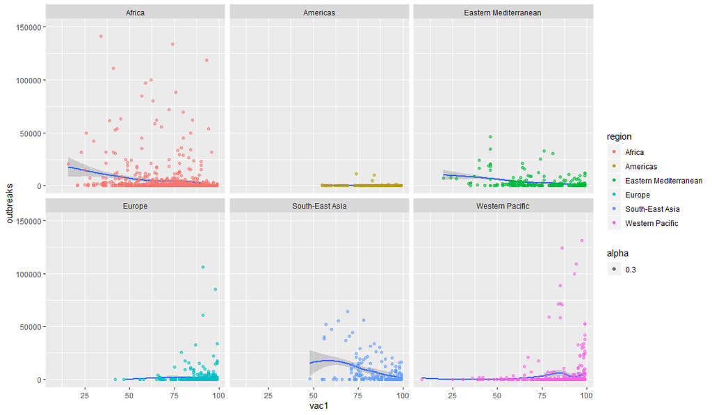

```r
MeaslesFull %>%
  ggplot() +
  stat_smooth(aes(x = vac1, y = outbreaks)) +
  geom_point(aes(x = vac1, y = outbreaks, alpha = 0.3, color = region)) +
  ylim(0, 150000) +
  facet_wrap(~ region)
```

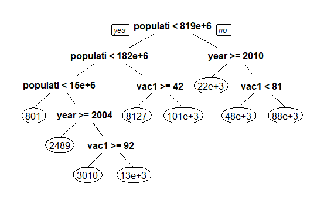

```r
mod1 <- rpart(outbreaks ~ vac1 + vac2 + population + pop_dens + distance + year, data = MeaslesFull)
prp(mod1)
```

Conclusions:  
**Machine Learning Conclusions**  
Countries with larget populations have more outbreaks. There were less outbreaks in countries with large populations if the year was greater than or equal to 2010. In countries with large populations before the year 2010, if there were less vaccinations there were less outbreaks. If there were more vaccinations there were more outbreaks. I found this surprising but it is likely due to the fact that many countries with large populations that vaccinate much of their population have few outbreaks but over the many years examined, the outbreaks add up to a many total.  
There were less outbreaks in countries with the smallest populations, which makes sense because if there are less people there are less people that could get the virus. In countries with medium sized populations, if more were vaccinated there were less outbreaks. In countries with smaller populations, if the year was 2004 or after there were less outbreaks. In those same countries, if the year was before 2004 and there were more vaccinations, there were less outbreaks observed.  
Some overall trends were that when populations were high there were more outbreaks and as the years progressed there were less outbreaks.  
**Other Conclusions**  
In Africa, South-East Asia, and the Eastern Mediterranean there was an overall negative correlation between first vaccinations and outbreaks. This was seen by the decreasing slope in the smoother lines. In Europe and the Americas, there were very few instances where countries had a high count of yearly outbreaks compared to the total number of instances with very few outbreaks. This was demonstrated by a very flat smoother line close to the x axis. The Western Pacific region was the most nonlinear and was the hardest to interpret. It seemed like there were many times where a country had high vaccination counts but still had high outbreaks. There were still many more occurances within the Western Pacific where there were high vaccination counts and low outbreak counts.